# 2013 College Scoreboard Analysis

Zihan Mo

April 17, 2018

Q1.

a.There are 3312 observations are recorded.

b.There are 2431 colleges are recorded based on main campus counts.

Q2

| Var1 | Freq |
| --- | --- |
| character | 4 |
| factor | 4 |
| integer | 15 |
| logical | 3 |
| numeric | 25 |

b.There are 5 types of features: character, factor, integer, logic, and numeric. And numeric can be considered as continuous.

Q3

a.There are 23197 missing values in the dataset.

b.avg_sat has the most missing value.

c.Information related to students privacy like score and family income has more NA. On the contrary, information related to school expense or teacher salary has relatively less NA.

Q4

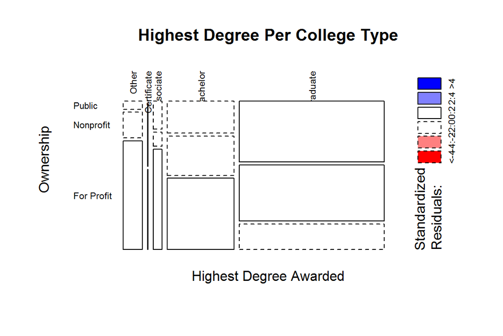

Public college does not provide certificate degree which only privat college provides; Graduate degree has more proportion than other degrees.

Q5

a.The average of undergraduate population is 3599.502 and the median is 1295.

b.Here is the deciles for undergraduate population

|  | x |
| --- | --- |
| 0% | 0.0 |
| 10% | 153.0 |
| 20% | 319.2 |
| 30% | 536.0 |
| 40% | 847.6 |
| 50% | 1295.0 |
| 60% | 1811.8 |
| 70% | 2674.5 |
| 80% | 4550.8 |
| 90% | 9629.8 |
| 100% | 166816.0 |

c.The undergraduate population has a right skewed distribution.

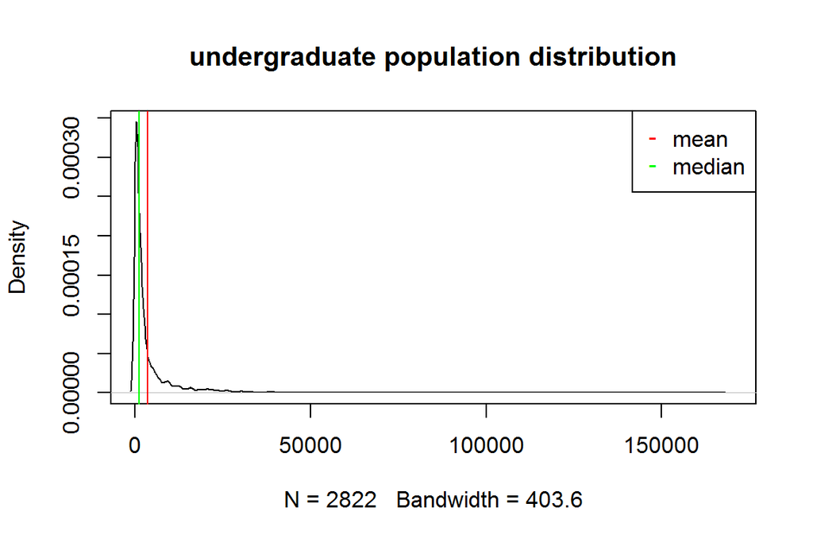

d.There is an unusual large undergraduate population which is 166816 in the data. Other campuses only have population below 70000.

Q6

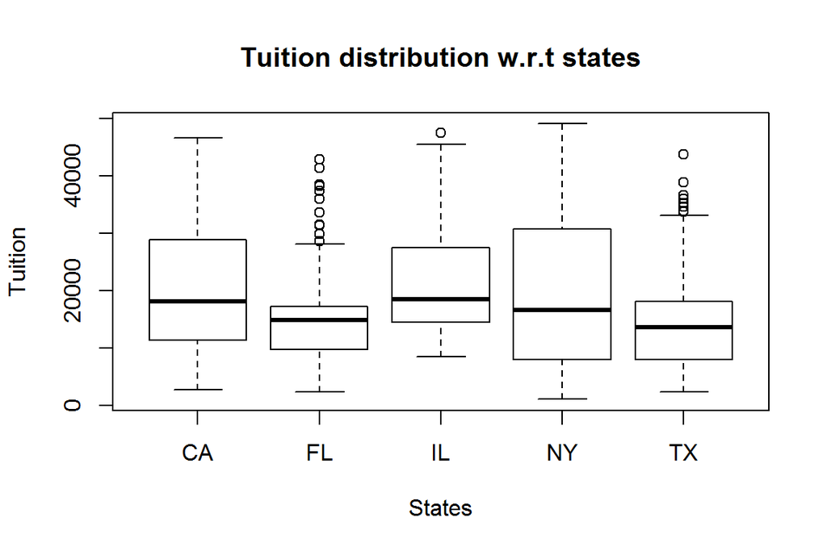

Based on the boxplots: a. All the states have similar median tuition; b. Gernerally, CA, NY, and IL have higher tuition.

Q7

```r
college_sat<-data[,c("name","avg_sat")]
highest_sat<-college_sat$avg_sat
college_sat[which.max(highest_sat),]
```

```
##                                   name avg_sat
## 105 California Institute of Technology    1534
```

```r
college_UG_pop <- data[, c("name","undergrad_pop","open_admissions")]
largest_UGpop<-college_UG_pop$undergrad_pop
college_UG_pop[which.max(largest_UGpop),]
```

```
##                                     name undergrad_pop open_admissions
## 2371 University of Phoenix-Online Campus        166816            TRUE
```

```r
fam_income<-data[,c("zip","avg_family_inc","ownership")]
P_fam_income<-subset(fam_income, ownership == "Public")
lowest_fminc<-which.min(P_fam_income$avg_family_inc)
P_fam_income[lowest_fminc,]
```

```
##        zip avg_family_inc ownership
## 1282 11101       5119.773    Public
```

```r
which.max(largest_UGpop)==which.max(data$grad_pop)
```

```
## [1] FALSE
```

The campus with the largest undergrad population doesn’t have the largest graduate population.

Q8

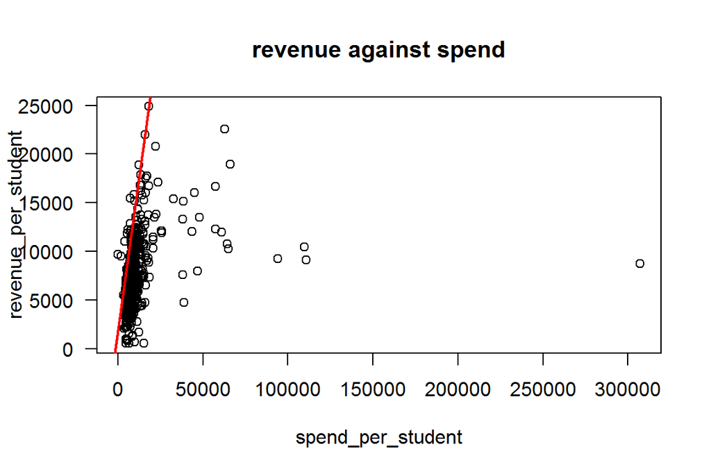

Revenue_per_student and spend_per_student have positive relationship. There are some outliers in the plot and they may affect the linear regression line.

| name | total_net_income |
| --- | --- |
| Pennsylvania State University-Main Campus | 313559820 |
| University of Maryland-University College | 275837415 |
| Temple University | 233274402 |
| Thomas Edison State University | 201713574 |
| Arizona State University-Tempe | 127186500 |

Q9

Part a

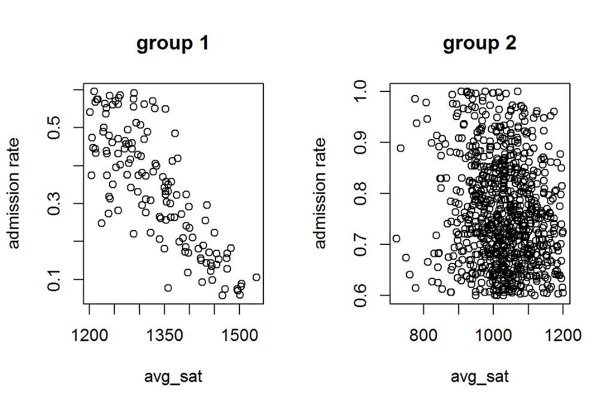

Split the data into two groups:

1.group 1 has avg_sat > 1200 and the admission rate < 0.6.

2.group 2 has avg_sat <= 1200 and the admission rate >= 0.6.

PART b

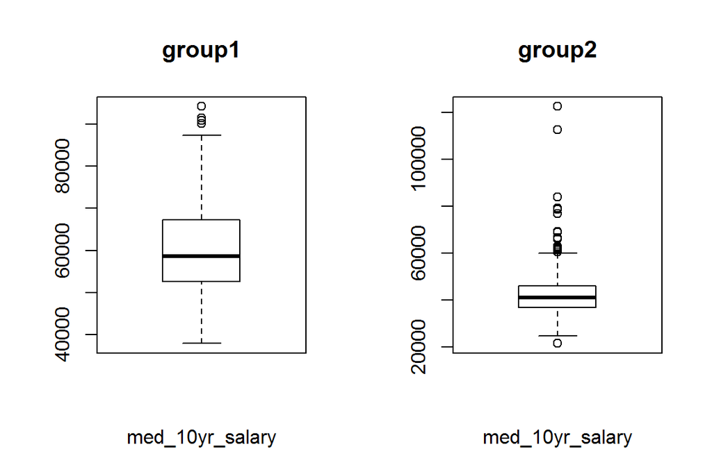

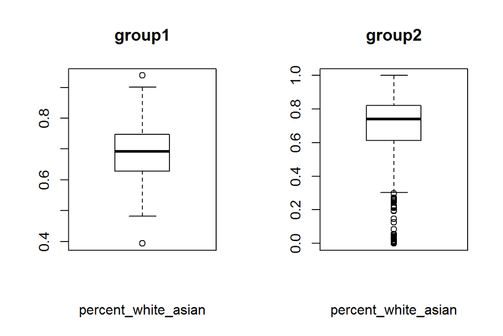

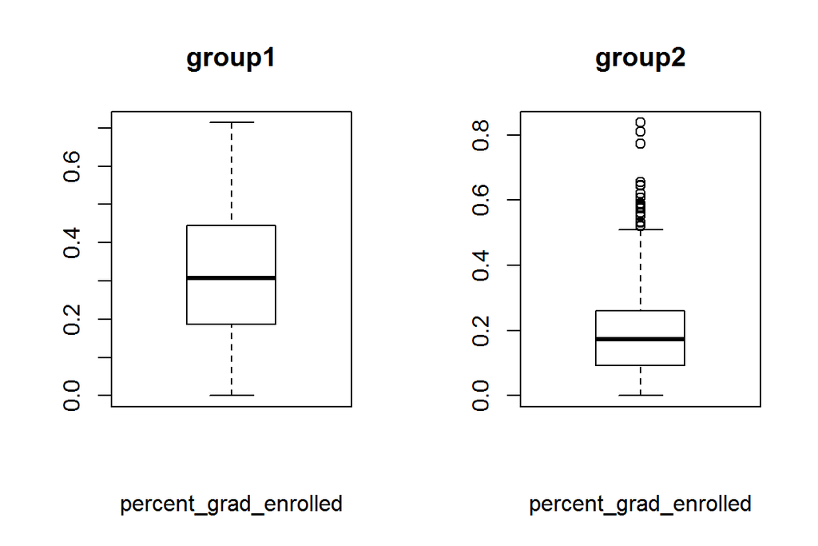

Based on the plots above, colleges in group 1 have higher percentage of graduate students enrolled. percentage of graduate students enrolled increases from group2 to group1.

PART C

```r
sum(data_group1$open_admissions)
```

```
## [1] 0
```

```r
sum(data_group2$open_admissions)
```

```
## [1] 0
```

In both groups, all the colleges are not open admission. Therefore, it’s fair to conclude open_admissions is independent of group.

```r
num_main_campus1<-sum(data_group1$main_campus)
num_main_campus2<-sum(data_group2$main_campus)
num_main_campus2/830
```

```
## [1] 0.9590361
```

```r
num_main_campus1/136
```

```
## [1] 1
```

In group1, 100% of colleges are main campus; in group 2, 96% of colleges are main campus. It’s fair to conclude main_campus is independent of group.

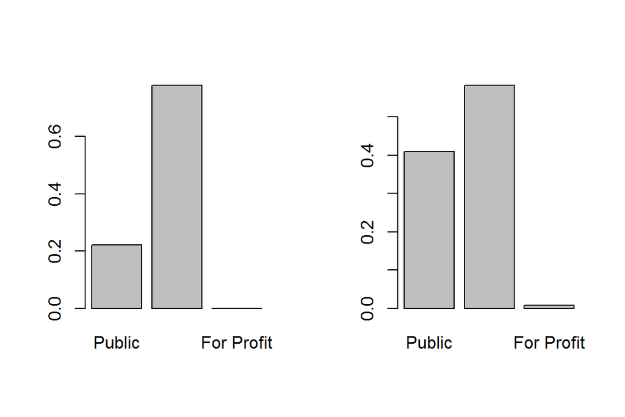

Based on the bar plots above, the percentage of public school in group 2 is twice as much as in group 1. For nonprofit decreases 19% from group 1 to group 2. But for profit almost doesn’t change. Therefore, it’s fair to conclude ownership is dependent of group.

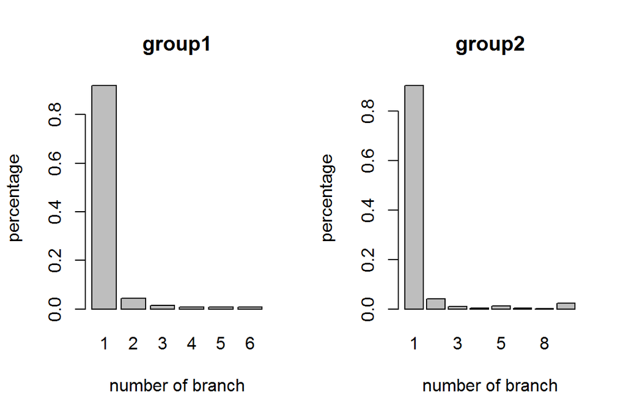

Based on the bar plots above, group 1 and group 2 have similar percentage distribution that 90% of the colleges have one branch. Therefore, it’s fair to conclude the variable “branch” is independent of group.

Q10

Part a

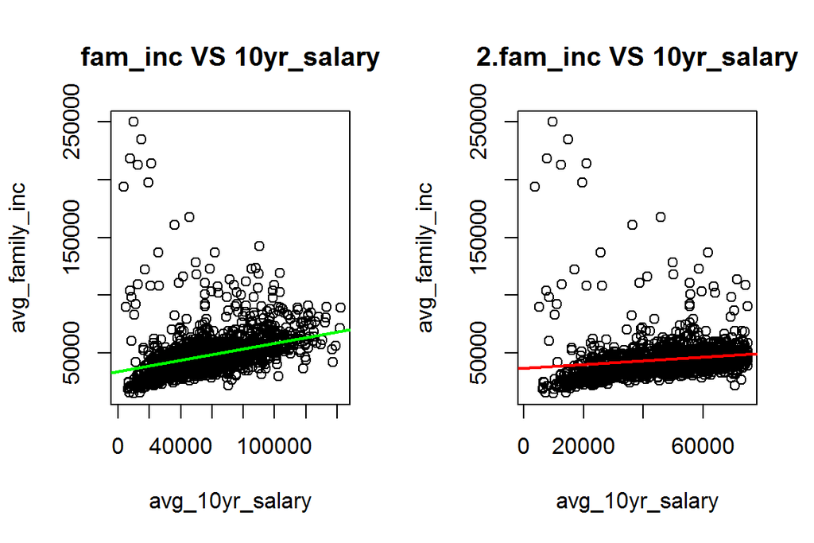

Part b

By adding categorial primary_degree, the adjusted R^2 increseases to 0.2525 from 0.1405. The levels of the variable is “other”, “Certificate”, “Associate”, “Bachelor”, and “Graduate”

###reference 1.Piazza 2.stackoverflow:https://stackoverflow.com/questions/12187891/how-to-get-top-n-companies-from-a-data-frame-in-decreasing-order

###Appendix

```r
data = readRDS('college_scorecard_2013.rds')
1
dim(data)
num_of_obs <- nrow(data)
head(data, n = 4L)
num_of_college <- sum(data$main_campus)

2
str(data)
table(sapply(data, class))
sapply(data, typeof)

3

total_num_NA<-sum(is.na(data))
NA_mat<-is.na(data)
non_NA_mat<-!is.na(data)
NA_counts<-colSums(is.na(data))
sort(NA_counts, decreasing = TRUE)
table(is.na(data$med_family_inc), data$ownership)
table(is.na(data$avg_sat),data$open_admissions)

4
table(factor(data$ownership=="Public",
             labels = c("Public", "Private")))
data$IsPublic<-factor(data$ownership=="Public",
                              labels=c("Private","Public"))
prop<-prop.table(table(data$highest_degree, data$ownership), margin = 2)
mosaicplot(prop,shade = TRUE,color = FALSE,
           main = "Highest Degree Per College Type",
           xlab = "Highest Degree Awarded", ylab = "Ownership", las=2)

5
UG_mean<-mean(data$undergrad_pop, na.rm = TRUE)
UG_med<-median(data$undergrad_pop, na.rm=TRUE)
quantile(data$undergrad_pop, na.rm = TRUE, probs = seq(0,1,0.1))
plot(density(data$undergrad_pop, na.rm = TRUE),
     main="undergrad population distribution",
     xlim=c(0,170000))
abline(v = UG_mean, col = "red", lwd = 1)
abline(v = UG_med, col = "green", lwd = 1)
legend("topright",legend=c('mean','median'),
       col=c("red","green"),pch="-")
boxplot(data$undergrad_pop)
summary(data$undergrad_pop)

6
populous_states<-data[data$state%in%c("CA","TX","NY","IL","FL"),]
fstate<-factor(populous_states$state)
boxplot(tuition~fstate, data = populous_states,na.rm=TRUE,
        main = "Tuition distribution w.r.t states",
        xlab = "States", ylab = "Tuition")

7
a.
college_sat<-data[,c("name","avg_sat")]
highest_sat<-college_sat$avg_sat
college_sat[which.max(highest_sat),]

b
college_UG_pop <- data[, c("name","undergrad_pop","open_admissions")]
largest_UGpop<-college_UG_pop$undergrad_pop
college_UG_pop[which.max(largest_UGpop),]

c
fam_income<-data[,c("zip","avg_family_inc","ownership")]
P_fam_income<-subset(fam_income, ownership == "Public")
lowest_fminc<-which.min(P_fam_income$avg_family_inc)
P_fam_income[lowest_fminc,]

d
which.max(largest_UGpop)==which.max(data$grad_pop)
data[which.max(data$grad_pop),"undergrad_pop"]

8
a
data2<-subset(data, ownership=="Public"&primary_degree=="Bachelor")
model1<-lm(data2$spend_per_student~data2$revenue_per_student)
plot(data2$spend_per_student, data2$revenue_per_student,
     xlab = "spend_per_student", ylab = "revenue_per_student",
     main = "revenue against spend",las = 1)
abline(model1, col="red", lwd = 2)

b
per_net_income<-data2$revenue_per_student-data2$spend_per_student
total_student_pop<-data2$undergrad_pop+data2$grad_pop
data2$total_net_income<-per_net_income*total_student_pop
data22<-data2[,c("name","total_net_income")]
head(arrange(data22,desc(total_net_income)), n = 5)

9
part A
data_group1<-subset(data, data$admission<0.6&data$avg_sat>1200)
data_group2<-subset(data, data$admission>=0.6&data$avg_sat<=1200)
par(mfrow = c(1,2))
plot(data_group1$avg_sat, data_group1$admission,
     main = "group 1", xlab = "avg_sat",
     ylab = "admission rate")
plot(data_group2$avg_sat, data_group2$admission,
     main = "group 2", xlab = "avg_sat",
     ylab = "admission rate")
r_group2<-cor(data_group2$avg_sat, data_group2$admission)
r_group1<-cor(data_group1$avg_sat, data_group1$admission)

PART B
a)
par(mfrow = c(1,2))
boxplot(data_group1$med_10yr_salary, na.rm = TRUE,
             xlab="med_10yr_salary", main = "group1")
boxplot(data_group2$med_10yr_salary,na.rm = TRUE,
     xlab="med_10yr_salary", main = "group2")

b)
data_group1$percen_white_asian1 <- data_group1$race_white+data_group1$race_asian
data_group2$percen_white_asian2 <- data_group2$race_white+data_group2$race_asian
par(mfrow = c(1,2))
boxplot(data_group1$percen_white_asian1, na.rm = TRUE,
     xlab="percen_white_asian", main = "group1")
boxplot(data_group2$percen_white_asian2,na.rm = TRUE,
     xlab="percen_white_asian", main = "group2")

c)
data_group1$percent_grad1<-data_group1$grad_pop/(data_group1$grad_pop+
  data_group1$undergrad_pop)
data_group2$percent_grad2<-data_group2$grad_pop/(data_group2$grad_pop+
  data_group2$undergrad_pop)
par(mfrow = c(1,2))
boxplot(data_group1$percent_grad1, na.rm = TRUE,
        xlab="percent_grad_enrolled", main = "group1")
boxplot(data_group2$percent_grad2, na.rm = TRUE,
        xlab="percent_grad_enrolled", main = "group2")

PART C
a)
num_open_ad1<-sum(data_group1$open_admissions)
num_open_ad2<-sum(data_group2$open_admissions)

b)
num_main_campus1<-sum(data_group1$main_campus)
num_main_campus2<-sum(data_group2$main_campus)
percentage2<-num_main_campus2/830
percentage1<-num_main_campus1/136

c)
tbl1<-table(data_group1$ownership)
tbl2<-table(data_group2$ownership)
percent1<-tbl1/136
percent2<-tbl2/830
par(mfrow=c(1,2))
barplot(percent1, main = "group1", xlab = "ownership",
        ylab = "percentage")
barplot(percent2, main = "group2", xlab = "ownership",
        ylab="percentage")

d)
tbl3<-table(data_group1$branches)
tbl4<-table(data_group2$branches)
percent3<-tbl3/136
percent4<-tbl4/830
barplot(percent3, main = "group1", xlab = "number of branch",
        ylab = "percentage")
barplot(percent4, main = "group2", xlab = "number of branch",
        ylab="percentage")

10
part A
par(mfrow=c(1,2))
plot(data$avg_family_inc,data$avg_10yr_salary,
     main = "fam_inc VS 10yr_salary",
     xlab="avg_10yr_salary",ylab="avg_family_inc")
fit1<-lm(data$avg_10yr_salary~data$avg_family_inc)
abline(fit1, col = "green", lwd=2)
data10 <- subset(data, avg_family_inc<=75000)
plot(data10$avg_family_inc,data10$avg_10yr_salary,
     main = "fam_inc VS 10yr_salary",
     xlab="avg_10yr_salary",ylab="avg_family_inc")
fit2<-lm(data10$avg_10yr_salary~data10$avg_family_inc)
abline(fit2, col = "red", lwd = 2)
summary(fit1)
summary(fit2)

PART B
fit3<-lm(data$avg_10yr_salary~data$avg_family_inc+data$primary_degree)
abline(fit3, col = "blue", lwd=2)
levels(data$primary_degree)
```